# Reproducibility Project 1

Jeffrey A. Walker

2023-11-08

# Motivation for these datasets

part 1:

1. 2 x 2 design. Design is balanced so Safe Anova not necessary to reproduce
2. Difference in significance is not necessarily significant fallacy.

part 2:

1. 2 x 2 design. Design is not balanced so Safe Anova is necessary to reproduce
2. Big p-value means “no effect” fallacy

# Important update!!!

Rename the data_from folder to:

“Sirtuin 6 inhibition protects against glucocorticoid-induced skeletal muscle atrophy by regulating IGF-PI3K-AKT signaling”

Note the hyphen between the gene names and not the slash character.

Using this title with the slash character “/” will result in a failed import because the “/” character is a universal character reserved for hierarchical directory structure – your computer will think there is a folder called “AKT signaling” inside a folder called “PI3K” inside a folder called “Sirtuin 6 inhibition protects against glucocorticoid-induced skeletal muscle atrophy by regulating IGF”.

# The assignment is

Reproduce the analysis of the experiment presented in Fig 3c and in Fig 4c of the article

[Mishra, Sneha, et al. “Sirtuin 6 inhibition protects against glucocorticoid-induced skeletal muscle atrophy by regulating IGF/PI3K/AKT signaling.” Nature communications 13.1 (2022): 5415.](https://www.nature.com/articles/s41467-022-32905-w)

dataset: Mishra-Sirtuin 6.xlsx

You need to 1) import the data, 2) analyze the data, and 3) report the results following the example in [Section 10.1.1](https://www.middleprofessor.com/files/applied-biostatistics_bookdown/_book/oneway#oneway-example1)

**From the abstract**: “Chronic activation of stress hormones such as glucocorticoids leads to skeletal muscle wasting in mammals. However, the molecular events that mediate glucocorticoid-induced muscle wasting are not well understood. Here, we show that SIRT6, a chromatin-associated deacetylase indirectly regulates glucocorticoid-induced muscle wasting by modulating IGF/PI3K/AKT signaling.”

# Part 1: Fig 3C

**Results leading up to the experiment in Fig 3c**: “Overall, these findings suggest that SIRT6 overexpression spontaneously induces expression of atrophy markers, reduces protein synthesis, and reduces myotube size in a cell- autonomous manner” About the data:

**Motivating question**: “Since SIRT6 overexpression reduces myotube diameter, we tested whether SIRT6 depletion could protect against Dex-induced reduction in myotube diameter.”

**Experimental Model** Cell cultures of myotubes taken from either wildtype or Sirt6 KO mice. A myotube is a muscle cell. Muscle cells are long, tube-shaped cells that have multiple nuclei because they form by fusion of multiple stem muscle cells (myoblasts)

**Author’s reported result** “Notably, we found that SIRT6 depletion significantly increases myotube diameter at the basal level (Fig. 3a–c)…Moreover, SIRT6-depleted myotubes did not show any significant reduction in their diameter upon Dex treatment, contrary to the control myotubes (Fig. 3a–c).”

**Response variable**: Fig 3c: Myotube diameter. The measure is divided by the mean of the reference (Control genotype /Veh dex), so the measure is unitless and relative to reference mean.

**Factor variables**

1. Factor 1: *genotype* with levels = (“Control”, “SIRT6-KD”)
- Control – the wildtype.
- SIRT6-KD – strain specific? SIRT6 knock down
2. Factor 2: *dex* with levels = (“Veh”, “Dex”)
- Veh – “vehicle”
- Dex – dexamethasone

**dexamethasone** is a glucocortacoid analog. A glucocortacoid is a catabolic steroid hormone that typically inhibits protein synthesis (necessary for muscle fiber growth) and will therefore promote muscle atrophy.

Groups:

1. Control/Veh – the negative control giving the background diameter
2. SIRT6-KD/Veh – A positive control on the focal treatment, which is SIRT6-KD/Dex. Expect the knock out to have increased diameter.
3. Control/Dex – the positive Dex control. Expect Dex to decrease diameter.
4. SIRT6-KD/Dex – the focal treatment. Does “SIRT6 depletion protect against Dex-induced reduction in myotube diameter”

Contrasts of interest: You do this!

Assignment:

1. Write out all contrasts and which are of interest and which are not, and why for both.
2. Reproduce the statistics given by the authors for the analysis in Fig. 3C, **including the ANOVA table and the table of contrasts**. They published the statistics in the original excel file. I’ve copied and pasted the statistics into the Excel file I’ve provided, on the same sheet as the data. You want your statistics to match these.
3. Plot the model using ggplot_the_response. Give the plot pretty x-axis and y-axis labels. See the section in the [Plotting Models](https://www.middleprofessor.com/files/bio413/applied_biostatistics/plotting-models.html#how-to-use-the-plot-the-model-functions) chapter in the textbook on using ggplot_the_response to understand the arguments of the functions. This plot will look something like the published plot but will be a little different and better.
4. Better than reproducibility - Think about this statement by the authors: “Moreover, SIRT6-depleted myotubes did not show any significant reduction in their diameter upon Dex treatment, contrary to the control myotubes (Fig. 3a–c).” What does “significant” mean here? What does this imply about the contrasts of interest?
5. Write a short statement communicating the inference – something more formal than what the authors wrote. Here is what the authors wrote:

Author summary: “Notably, we found that SIRT6 depletion significantly increases myotube diameter at the basal level (Fig. 3a–c)…Moreover, SIRT6-depleted myotubes did not show any significant reduction in their diameter upon Dex treatment, contrary to the control myotubes (Fig. 3a–c).”

## Import

```r
data_from <- "Sirtuin 6 inhibition protects against glucocorticoid-induced skeletal muscle atrophy by regulating IGF-PI3K-AKT signaling"
file_name <- "Mishra-Sirtuin 6.xlsx"
file_path <- here(data_folder, data_from, file_name)
fig3c <- read_excel(file_path,
                    sheet = "Figure 3c",
                    range = "A1:C37") |>
  data.table()
dex_levels <- c("Veh", "Dex")
fig3c[, dex := factor(dex, levels = dex_levels)]

# the hyphen in the group name SIRT6-KD is awkward with contrasts so change to underscore
fig3c[genotype == "SIRT6-KD", genotype := "SIRT6_KD"]

genotype_levels <- c("Control", "SIRT6_KD")
fig3c[, genotype := factor(genotype, levels = genotype_levels)]
```

## Contrasts of interest

1. Dex - Control: Dexamethasone is a steroid hormone that is known to cause muscle atrophy. We expect this to decrease diameter. This isn’t a discovery but simply a positive control.
2. SIRT6-KD - Control: Previous results showed overexpression caused muscle wasting. The expectation is KD will result in increased diameter. This would be a discovery.
3. Both - Dex: We want to compare the effect of SIRT6-KD both without and with Dex. Without is contrast 2. This is the with-Dex contrast.
4. Interaction: (Both - Dex) - (SIRT6-KD - Control) - this is the difference in the effect of SIRT6 KD with and without Dex.
   - if effectively zero (“no” interaction) then suggests that SIRT6 works independently of Dex
   - if big and negative then suggests that Dex inhibits consquences of SIRT6 KD
   - if big and positive then suggests that SIRT6 KD can inhibit effects of Dex. This is the authors model or what they are exploring or why they are pursuing SIRT6.

## Reproducibility

### Anova table

```r
type3 <- list(genotype = contr.sum,
              dex = contr.sum)
fig3c_m1 <- lm(myotube_diameter ~ genotype * dex,
         contrasts = type3, # safe anova
         data = fig3c)
fig3c_anova <- Anova(fig3c_m1, type = "3") |>
  as.data.frame()
fig3c_anova[-c(1,5),] |>
  kable(digits = c(2,1,2,4)) |>
  kable_styling()
```

|  | Sum Sq | Df | F value | Pr(>F) |
| --- | --- | --- | --- | --- |
| genotype | 2.21 | 1 | 45.03 | 0.0000 |
| dex | 0.88 | 1 | 17.86 | 0.0002 |
| genotype:dex | 0.06 | 1 | 1.25 | 0.2719 |

Author’s ANOVA table

Source of Variation P value siRNA < 0.0001 Dex 0.0002 Interaction 0.2719

The anova reproduces that of the authors.

### Contrasts

```r
# fig3c_m1 <- lm(myotube_diameter ~ genotype * dex,
#         data = fig3c)

# the fit model in the chunk with the sum coded contrasts in the chunk with the ANOVA
# give the same emmeans and contrasts as the default dummy coded contrasts, so I commented out
# the two lines above. The two fit models will differ in the model coefficients because
# the coefs have a different interpretation -- one is differences from group mean and one is
# differences from the reference mean.

fig3c_emm <- emmeans(fig3c_m1, specs = c("genotype", "dex"))

# researchers based bonferroni on all 6 pairs but only show the four simple effects so
# super conservative! So here is how I'm going to do this
# 1. compute all six
# 2. copy the contrast object with only the subset of simple effects
# One could also
# 1. compute only the simple effects with no adjustment and then
# 2. multiple the column of p-values by 6 for the bonferroni adjusment and then
# 3. change any p-value >1 to something like "0.99999999"

fig3c_pairs <- contrast(fig3c_emm,
               method = "revpairwise",
               adjust = "bonferroni") |>
  summary(infer = TRUE)

fig3c_simple <- fig3c_pairs[c(2,1,6,5), ] # keep only the four simple effects, and in order of authors table
fig3c_simple |>
  kable(digits = c(1,3,3,1,3,3,2,4)) |>
  kable_styling()
```

|  | contrast | estimate | SE | df | lower.CL | upper.CL | t.ratio | p.value |
| --- | --- | --- | --- | --- | --- | --- | --- | --- |
| 2 | Control Dex - Control Veh | -0.395 | 0.104 | 32 | -0.689 | -0.101 | -3.78 | 0.0039 |
| 1 | SIRT6_KD Veh - Control Veh | 0.413 | 0.104 | 32 | 0.119 | 0.707 | 3.95 | 0.0024 |
| 6 | SIRT6_KD Dex - Control Dex | 0.578 | 0.104 | 32 | 0.285 | 0.872 | 5.54 | 0.0000 |
| 5 | SIRT6_KD Dex - SIRT6_KD Veh | -0.230 | 0.104 | 32 | -0.524 | 0.064 | -2.20 | 0.2117 |

Author’s contrast table:

```
                              P value
```

Control:Veh vs. Control:Dex 0.0039 Control:Veh vs. SIRT6-KD:Veh 0.0024 Control:Dex vs. SIRT6-KD:Dex < 0.0001 SIRT6-KD:Veh vs. SIRT6-KD:Dex 0.2117

The contrasts reproduces that of the authors.

## Plot the model

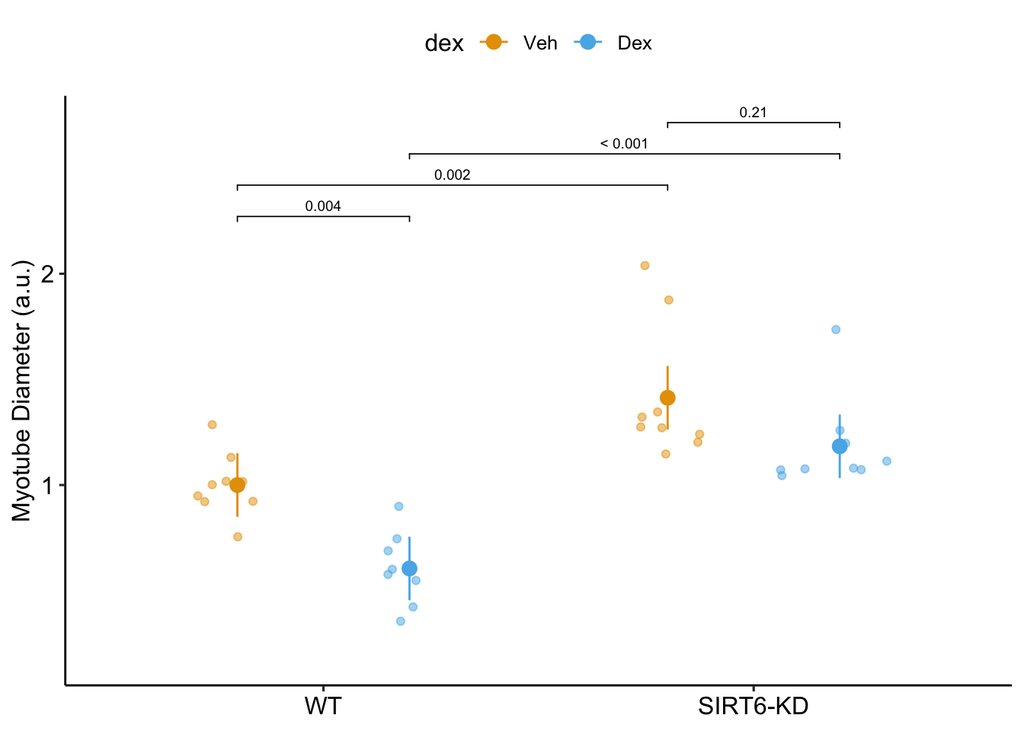

```r
gg1 <- ggplot_the_response(fig3c_m1, fig3c_emm, fig3c_simple,
                           y_label = "Myotube Diameter (a.u.)") +
  scale_x_discrete(labels = c("WT", "SIRT6-KD"))

gg1
```

## Better than reproducibility

Think about this statement by the authors: “Moreover, SIRT6-depleted myotubes did not show any significant reduction in their diameter upon Dex treatment, contrary to the control myotubes (Fig. 3a–c).” What does “significant” mean here? What does this imply about the contrasts of interest?

The authors are inferring that “something different” is going on with SIRT6-KD with and without Dex – that is between the KD:Dex - Veh contrast (the right two groups in the plot) and the CN:Dex - Veh contrast (left two groups) – since the without-SIRT6-KD contrast is significant but the with-Sirt-KD contrast is not. This is known as the “A difference in significance is significant” fallacy. They are literally inferring that the interaction is significant from this difference in significance…but it’s not. Just look at the interaction p-value!

```r
control = c(1,0,0,0)
sirt6_kd = c(0,1,0,0)
dex = c(0,0,1,0)
both = c(0,0,0,1)

planned = list(
  "Dex" = dex - control,
  "SIRT6_KD_no_dex" = sirt6_kd - control,
  "SIRT6_KD_dex" = both - dex,
  "Interaction" = (both - dex) - (sirt6_kd - control)
)

fig3c_planned <- contrast(fig3c_emm,
                          method = planned,
                          adjust = "none") |>
  summary(infer = TRUE)

fig3c_planned |>
  kable(digits = c(1,2,2,1,2,2,2,4)) |>
  kable_styling()
```

| contrast | estimate | SE | df | lower.CL | upper.CL | t.ratio | p.value |
| --- | --- | --- | --- | --- | --- | --- | --- |
| Dex | -0.39 | 0.10 | 32 | -0.61 | -0.18 | -3.78 | 0.0006 |
| SIRT6_KD_no_dex | 0.41 | 0.10 | 32 | 0.20 | 0.63 | 3.95 | 0.0004 |
| SIRT6_KD_dex | 0.58 | 0.10 | 32 | 0.37 | 0.79 | 5.54 | 0.0000 |
| Interaction | 0.17 | 0.15 | 32 | -0.14 | 0.47 | 1.12 | 0.2719 |

## Report the results

# Part II. Fig. 4C

**Motivating question**: “Since our in vitro findings suggest that SIRT6 depletion protects myotubes against Dex-induced reduction in size, we tested whether msSIRT6-KO mice are resistant to Dex-induced skeletal muscle wasting” [the “ms” in msSIRT6-KO is muscle-specific]

**Experimental Model** Whole mice using [muscle-specific knock out using cre-lox system](https://www.jax.org/news-and-insights/jax-blog/2011/September/cre-lox-breeding).

**Author’s reported result** “Similarly, we observed a significant reduction in muscle mass of tibialis anterior (Fig. 4c and Supplementary Fig. 12B) and gastrocnemius muscle (Supplementary Fig. 12C and D) of Dex-treated control mice, while msSIRT6-KO mice were resistant to Dex-induced atrophy (Fig. 4c and Supplementary Fig. 12B–D). However, Dex treatment did not cause any significant change in muscle weights of the quadriceps, triceps, or biceps (Supplementary Fig. 12E–J).”

**Response variable**: Fig 4c: Percent change in muscle mass (the authors use percent muscle “loss” but the muscle in some individuals increased in size.). It’s also not clear to me how change was measured since it’s not change in an individual mouse, but we’ll just go with it.

**Factor variables**

1. Factor 1: *genotype* with levels = (“SIRT6-fl/fl”, “msSIRT6-KO”)
- SIRT6-fl/fl – the flox/flox mouse with the transgene but not knocked out.
- msSIRT6-KO – muscle specific SIRT6 knock out
2. Factor 2: *dex* with levels = (“Veh”, “Dex”)
- Veh – “vehicle”
- Dex – dexamethasone

**dexamethasone** is a glucocortacoid analog. A glucocortacoid is a catabolic steroid hormone that typically inhibits protein synthesis (necessary for muscle fiber growth) and will therefore promote muscle atrophy.

Groups:

1. SIRT6-fl/fl/Veh – the negative control giving the background change in muscle mass.
2. msSIRT6-KO/Veh – the positive knockout control.
3. SIRT6-fl/fl/Dex – the positive Dex control.
4. msSIRT6-KO/Dex – the focal treatment.

Contrasts of interest: You do this!

Assignment:

1. Write out all contrasts and which are of interest and which are not, and why for both.
2. Reproduce the statistics given by the authors for the analysis in Fig. 3C, **including the ANOVA table and the table of contrasts**. They published the statistics in the original excel file. I’ve copied and pasted the statistics into the Excel file I’ve provided, on the same sheet as the data. You want your statistics to match these.
3. Plot the model using ggplot_the_response. Give the plot pretty x-axis and y-axis labels. See the section in the [Plotting Models](https://www.middleprofessor.com/files/bio413/applied_biostatistics/plotting-models.html#how-to-use-the-plot-the-model-functions) chapter in the textbook on using ggplot_the_response to understand the arguments of the functions. This plot will look something like the published plot but will be a little different and better.
4. Better than reproducibility - Think about this statement by the authors: “while msSIRT6-KO mice were resistant to Dex-induced atrophy” Do they have good evidence for this? What does this imply about the contrasts of interest?
5. Write a short statement communicating the inference – something more formal than what the authors wrote. Here is what the authors wrote:

Author summary: “Similarly, we observed a significant reduction in muscle mass of tibialis anterior (Fig. 4c and Supplementary Fig. 12B) and gastrocnemius muscle (Supplementary Fig. 12C and D) of Dex-treated control mice, while msSIRT6-KO mice were resistant to Dex-induced atrophy (Fig. 4c and Supplementary Fig. 12B–D). However, Dex treatment did not cause any significant change in muscle weights of the quadriceps, triceps, or biceps (Supplementary Fig. 12E–J).”

## Import fig4c

```r
data_from <- "Sirtuin 6 inhibition protects against glucocorticoid-induced skeletal muscle atrophy by regulating IGF-PI3K-AKT signaling"
file_name <- "Mishra-Sirtuin 6.xlsx"
file_path <- here(data_folder, data_from, file_name)
fig4c <- read_excel(file_path,
                    sheet = "Figure 4c",
                    range = "A1:C42") |>
  data.table()
dex_levels <- c("Veh", "Dex")
fig4c[, dex := factor(dex, levels = dex_levels)]

# the hyphen in the group name SIRT6-KD is awkward with contrasts so change to underscore
fig4c[genotype == "SIRT6-KD", genotype := "SIRT6_KD"]

genotype_levels <- c("SIRT6-fl/fl", "msSIRT6-KO")
fig4c[, genotype := factor(genotype, levels = genotype_levels)]
```

## Contrasts of interest

1. Dex - Control: Dexamethasone is a steroid hormone that is known to cause muscle atrophy. We expect this to decrease diameter. This isn’t a discovery but simply a positive control.
2. KO - Control: Followup of above in whole mice instead of cell culture. The expectation is KO will result in increased muscle mass. This would be a confirmation or rigorous probing of model.
3. Both - Dex: We want to compare the effect of KO both without and with Dex. Without is contrast 2. This is the with-Dex contrast.
4. Interaction: (Both - Dex) - (KO - Control) - this is the difference in the effect of SIRT6 KD with and without Dex.
   - if effectively zero (“no” interaction) then suggests that SIRT6 works independently of Dex
   - if big and negative then suggests that Dex inhibits consquences of KO
   - if big and positive then suggests that KO can inhibit effects of Dex. This is the author’s model or what they are exploring or why they are pursuing SIRT6.

## Reproducibility

### Anova table

```r
type3 <- list(genotype = contr.sum,
              dex = contr.sum)
fig4c_m1 <- lm(percent_muscle_change ~ genotype * dex,
         contrasts = type3, # safe anova
         data = fig4c)
fig4c_anova <- Anova(fig4c_m1, type = "3") |>
  as.data.frame()
fig4c_anova[-c(1,5),] |>
  kable(digits = c(2,1,2,4)) |>
  kable_styling()
```

|  | Sum Sq | Df | F value | Pr(>F) |
| --- | --- | --- | --- | --- |
| genotype | 590.73 | 1 | 1.13 | 0.2949 |
| dex | 11202.92 | 1 | 21.41 | 0.0000 |
| genotype:dex | 590.73 | 1 | 1.13 | 0.2949 |

Author’s ANOVA table

Source of Variation P value genotype 0.2949 Dex < 0.0001 Interaction 0.2949

The anova reproduces that of the authors.

### Contrasts

```r
# fig4c_m1 <- lm(percent_muscle_change ~ genotype * dex,
#         data = fig4c)

# the fit model in the chunk with the sum coded contrasts in the chunk with the ANOVA
# give the same emmeans and contrasts as the default dummy coded contrasts, so I commented out
# the two lines above. The two fit models will differ in the model coefficients because
# the coefs have a different interpretation -- one is differences from group mean and one is
# differences from the reference mean.

fig4c_emm <- emmeans(fig4c_m1, specs = c("genotype", "dex"))

# researchers based bonferroni on all 6 pairs but only show the four simple effects so
# super conservative! So here is how I'm going to do this
# 1. compute all six
# 2. copy the contrast object with only the subset of simple effects
# One could also
# 1. compute only the simple effects with no adjustment and then
# 2. multiple the column of p-values by 6 for the bonferroni adjusment and then
# 3. change any p-value >1 to something like "0.99999999"

fig4c_pairs <- contrast(fig4c_emm,
               method = "revpairwise",
               adjust = "bonferroni") |>
  summary(infer = TRUE)

fig4c_simple <- fig4c_pairs[c(2,1,6,5), ] # keep only the four simple effects, and in order of authors table
fig4c_simple |>
  kable(digits = c(1,3,3,1,3,3,2,4)) |>
  kable_styling()
```

|  | contrast | estimate | SE | df | lower.CL | upper.CL | t.ratio | p.value |
| --- | --- | --- | --- | --- | --- | --- | --- | --- |
| 2 | (SIRT6-fl/fl Dex) - (SIRT6-fl/fl Veh) | -40.974 | 9.549 | 37 | -67.592 | -14.357 | -4.29 | 0.0007 |
| 1 | (msSIRT6-KO Veh) - (SIRT6-fl/fl Veh) | 0.000 | 10.282 | 37 | -28.661 | 28.661 | 0.00 | 1.0000 |
| 6 | (msSIRT6-KO Dex) - (SIRT6-fl/fl Dex) | 15.304 | 10.087 | 37 | -12.815 | 43.422 | 1.52 | 0.8263 |
| 5 | (msSIRT6-KO Dex) - (msSIRT6-KO Veh) | -25.671 | 10.783 | 37 | -55.730 | 4.389 | -2.38 | 0.1353 |

Author’s contrast table:

```
                                  P value
```

SIRT6-fl/fl:Veh vs. SIRT6-fl/fl:Dex 0.0007 SIRT6-fl/fl:Veh vs. msSIRT6-KO:Veh > 0.9999 SIRT6-fl/fl:Dex vs. msSIRT6-KO:Dex 0.8263 msSIRT6-KO:Veh vs. msSIRT6-KO:Dex 0.1353

The contrasts reproduces that of the authors.

## Plot the model

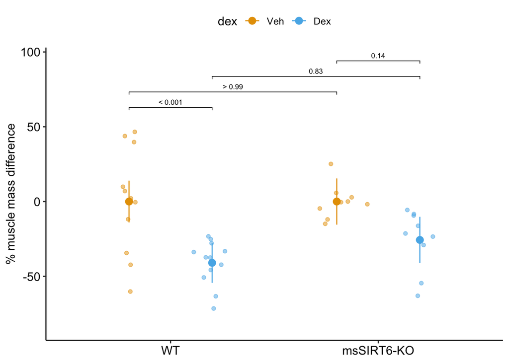

```r
gg1 <- ggplot_the_response(fig4c_m1, fig4c_emm, fig4c_simple,
                           y_label = "% muscle mass difference") +
  scale_x_discrete(labels = c("WT", "msSIRT6-KO"))

gg1
```

## Better than reproducibility

Think about this statement by the authors: “while msSIRT6-KO mice were resistant to Dex-induced atrophy” Do they have good evidence for this? What does this imply about the contrasts of interest?

The authors have made the “a high p-value means no effect” error. The authors are interpreting that the p = 0.14 > 0.05 = “N.S.” result indicates no effect of Dex in the KO mice meaning that these are “resistant to dex-induced atrophy”. But p-values don’t give us the evidence to say there is no effect. Indeed, the mean of the dex mice is well below that of the no-dex mice in the KO contrast. The data are consistent with “no effect” and “effect” – that is, the data are ambiguous or not clear.

```r
control = c(1,0,0,0)
sirt6_kd = c(0,1,0,0)
dex = c(0,0,1,0)
both = c(0,0,0,1)

planned = list(
  "Dex" = dex - control,
  "SIRT6_KD_no_dex" = sirt6_kd - control,
  "SIRT6_KD_dex" = both - dex,
  "Interaction" = (both - dex) - (sirt6_kd - control)
)

fig4c_planned <- contrast(fig4c_emm,
                          method = planned,
                          adjust = "none") |>
  summary(infer = TRUE)

fig4c_planned |>
  kable(digits = c(1,2,2,1,2,2,2,4)) |>
  kable_styling()
```

| contrast | estimate | SE | df | lower.CL | upper.CL | t.ratio | p.value |
| --- | --- | --- | --- | --- | --- | --- | --- |
| Dex | -40.97 | 9.55 | 37 | -60.32 | -21.63 | -4.29 | 0.0001 |
| SIRT6_KD_no_dex | 0.00 | 10.28 | 37 | -20.83 | 20.83 | 0.00 | 1.0000 |
| SIRT6_KD_dex | 15.30 | 10.09 | 37 | -5.13 | 35.74 | 1.52 | 0.1377 |
| Interaction | 15.30 | 14.40 | 37 | -13.88 | 44.49 | 1.06 | 0.2949 |

## Report the results

(reported from my non-adjusted p-values)

Truthfully, it’s just hard for me to interpret the results because of how they constructed the response variable – see below. This also messes up the contrasts of interest stated above. But, let’s pretend everything is okay, I’ll just interpret the interaction.

“We don’t have evidence to reject the model that SIRT6 and Dexamethasone work additively (not interacting) (Interaction = 15.3%; 95% CI: -13.9, 44.5; p = 0.29), which rejection is necessary to support the model that SIRT6 is a mediator of steroid-induced muscle wasting.”

## Extra! Don’t do this!

That said - look at the p-value the SIRT6_KD_no_dex contrast above. It is effectively 1.0. This should raise a huuuuuge red flag. The reason this p is effectively 1 is because of how the authors created the response variable, which is:

$$\frac{weight_{post} -
\overline{weight}_{pre}}{\overline{weight}_{pre}}$$
where $\overline{weight}_{pre}$ is the mean weight of the Veh group with or without SIRT6-KO

So the means of the two vehicle groups should be exactly zero if I’m correct about what they did. You can see this with the estimated marginal means table, although these means of the two Veh groups aren’t precisely zero. Maybe it’s rounding error because they used a mean rounded to a few decimal places?

```r
fig4c_emm |>
  kable(digits = c(1,1,7,2,1,1,1)) |>
  kable_styling(full_width = FALSE)
```

| genotype | dex | emmean | SE | df | lower.CL | upper.CL |
| --- | --- | --- | --- | --- | --- | --- |
| SIRT6-fl/fl | Veh | 0.0000045 | 6.90 | 37 | -14.0 | 14.0 |
| msSIRT6-KO | Veh | 0.0000029 | 7.62 | 37 | -15.4 | 15.4 |
| SIRT6-fl/fl | Dex | -40.9743500 | 6.60 | 37 | -54.4 | -27.6 |
| msSIRT6-KO | Dex | -25.6706844 | 7.62 | 37 | -41.1 | -10.2 |

What this does it completely remove the effect of KO in the Veh group! The interaction effect then makes no sense because we’ve forced the difference in the Veh groups to be zero. Ugggggggg.

In general, don’t analyze pre-post data as a difference (post-pre) or as a percent change (diff/start) AND especially don’t normalize by the mean pre value.

Here is the best practice model, if you have the weight of the post mice at the time of pre (baseline)

```r
fig4c_m1 <- lm(muscle_weight_post ~ genotype * dex + body_weight_pre, data = fig4c)
```

This model makes more assumptions

```r
fig4c_m1 <- lm(muscle_weight_post ~ genotype * dex + body_weight_post, data = fig4c)
```

In these models, body_weight is used as an added covariate – the classical anova for this is called ANCOVA – analysis of covariance. For more on this, see the linear models for added covariates chapter.